# Лабораторная работа №1

Основы информационной безопасности

Чистов Д. М.

Российский университет дружбы народов, Москва, Россия

Объединённый институт ядерных исследований, Дубна, Россия

22 февраля 2025

# Цель работы

Целью данной работы является приобретение практических навыков установки операционной системы на виртуальную машину, настройки минимально необходимых для дальнейшей работы сервисов

# Задания

1. Настройка виртуальной машины и установка операционной системы
2. Домашнее задание

# Выполнение лабораторной работы

## Настройка виртуальной машины и установка операционной системы

Я выполнял работу дома на стационарном компьютере, пользовался VirtualBox, по заданию требуется поставить ОС Rocky, я скачал её образ с официального сайта. Перейдём к процессу настройки виртуальной машины.

## Настройка виртуальной машины и установка операционной системы

Задаю имя виртуальной машины согласно требованиям к наименованию, также задаю путь и выбираю нужный образ, скачанный с интернета.

[figure not shown]

Первоначальные настройки виртуальной машины

## Настройка виртуальной машины и установка операционной системы

Выбираю кол-во процессоров и выделяю нужное мне кол-во памяти.

[figure not shown]

Настройка виртуальной машины

## Настройка виртуальной машины и установка операционной системы

Выделяю нужное количество память жёсткого диска для моей виртуальной машины.

[figure not shown]

Количество памяти

## Настройка виртуальной машины и установка операционной системы

Итоговые настройки моей виртуальной машины.

[figure not shown]

Финальные параметры виртуальной машины

## Настройка виртуальной машины и установка операционной системы

Запускаю виртуальную машину и вижу, что установка успешно начата.

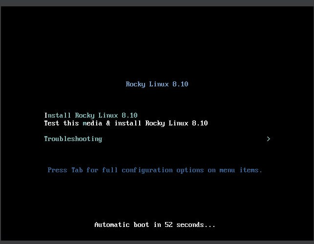

Начало установки операционной системы

## Настройка виртуальной машины и установка операционной системы

Задаю язык операционной системы.

[figure not shown]

Язык операционной системы

## Настройка виртуальной машины и установка операционной системы

Задаю часовой пояс операционной системы - Москва, Московское время.

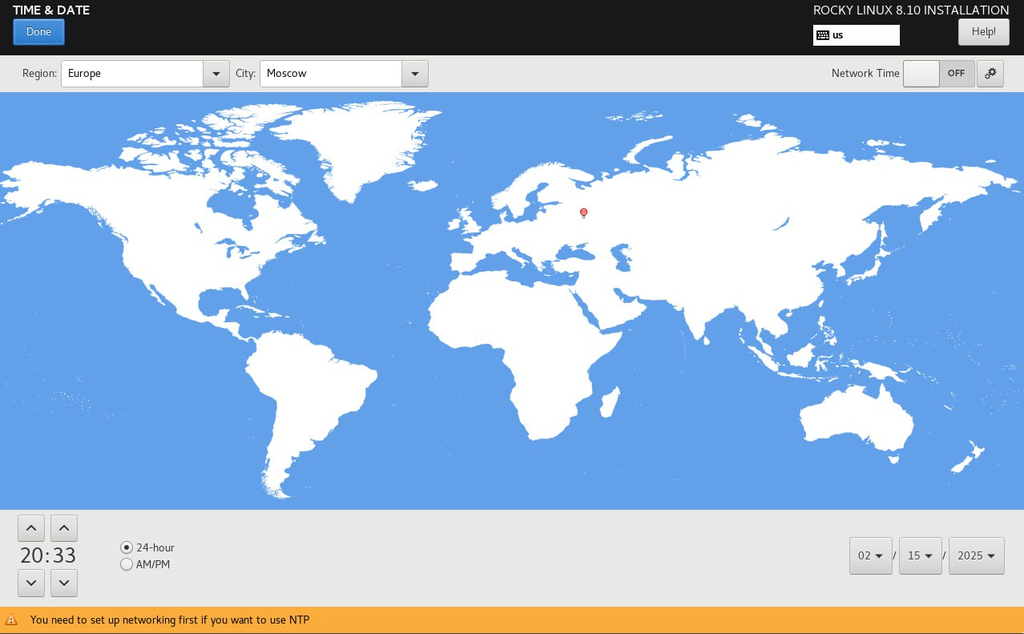

Часовой пояс виртуальной машины

## Настройка виртуальной машины и установка операционной системы

В разделе выбора программ, указываю базовое окружение - Server with GUI, а в качестве дополнения - Development tools.

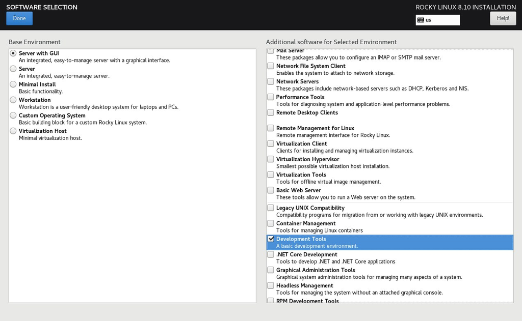

Server with GUI, Development tools

## Настройка виртуальной машины и установка операционной системы

Настриваю клавиатуру - выбираю раскладку: русскую и английскую.

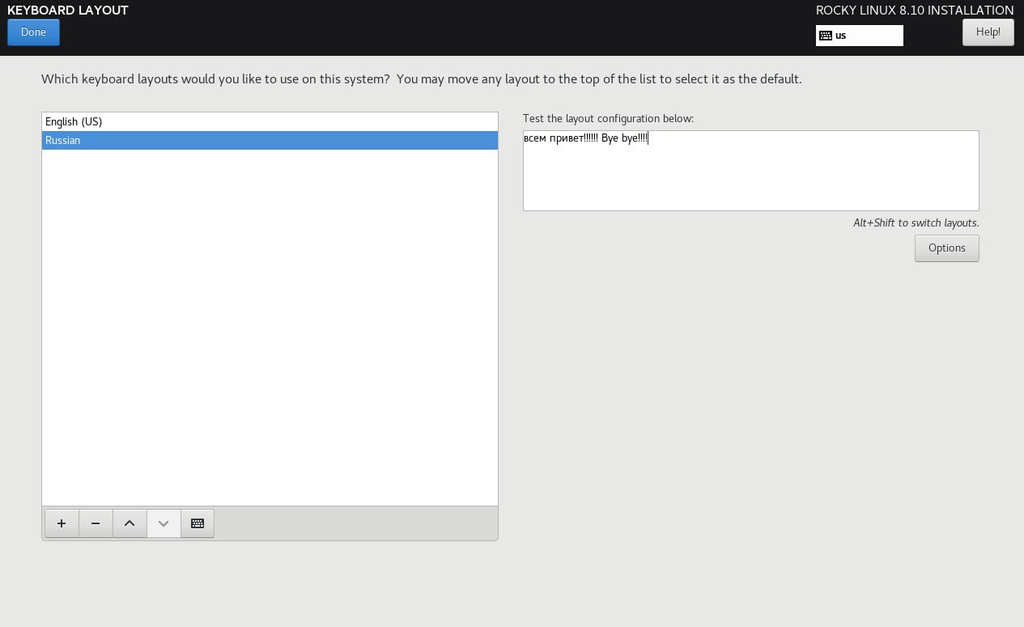

Настройка клавиатуры

## Настройка виртуальной машины и установка операционной системы

Отключаю KDUMP.

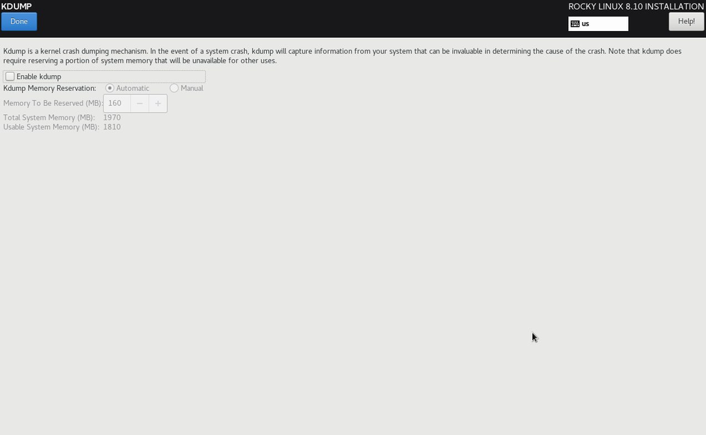

Отключение KDUMP

## Настройка виртуальной машины и установка операционной системы

Включаю сетевое соединение, а в качестве имени узла указываю dmchistov.localdomain.

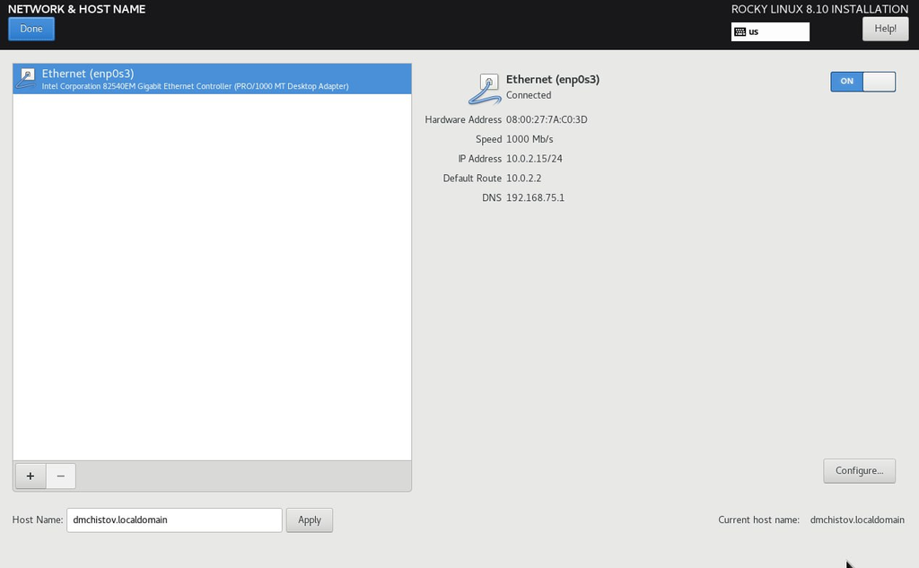

Настройка сети

## Настройка виртуальной машины и установка операционной системы

Устанавливаю пароль для root.

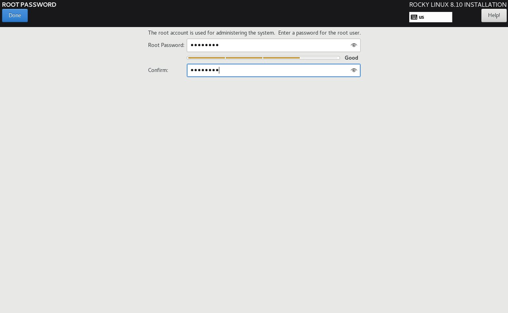

пароль для root-доступа

## Настройка виртуальной машины и установка операционной системы

Создаю пользователя dmchistov и задаю ему пароль.

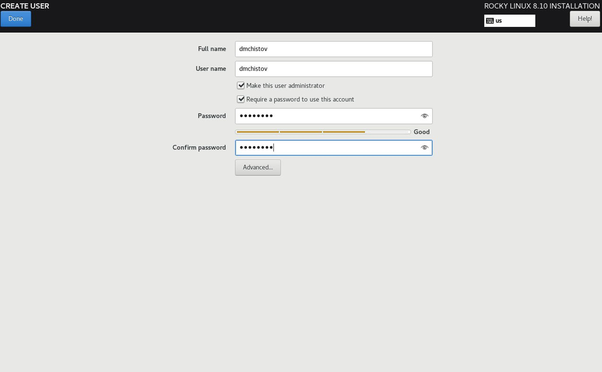

Новый пользователь

## Настройка виртуальной машины и установка операционной системы

Выбираю свой виртуальный жёсткий диск.

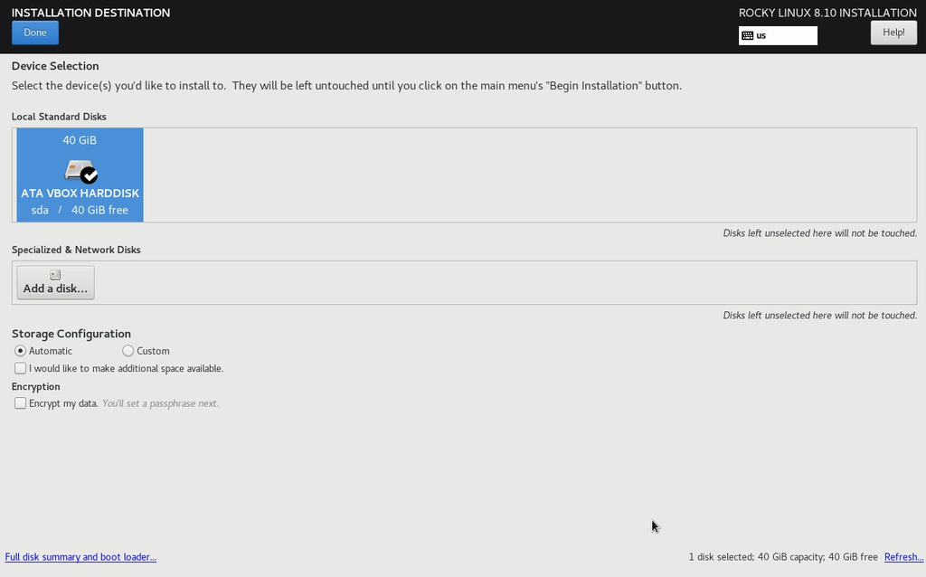

Жёсткий диск для операционной системы

## Настройка виртуальной машины и установка операционной системы

Начальная настройка операционной системы завершена, перейду к установке.

[figure not shown]

Начальные настроки ОС

## Настройка виртуальной машины и установка операционной системы

Установка ОС.

[figure not shown]

Установка

## Настройка виртуальной машины и установка операционной системы

Установка завершена.

[figure not shown]

Установка завершена

## Настройка виртуальной машины и установка операционной системы

Проверяю, что образ успешно автоматически исчез после установки и больше и не используется.

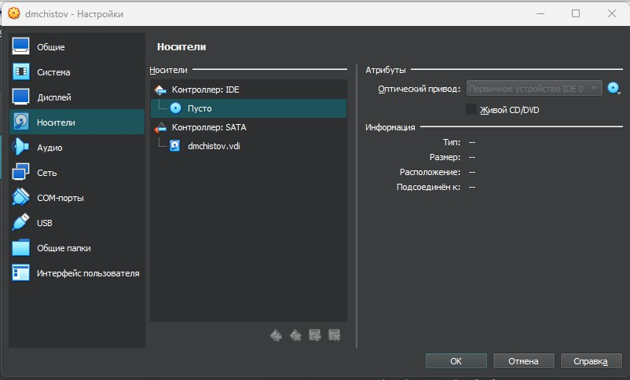

Образа больше нет

## Настройка виртуальной машины и установка операционной системы

Подтверждаю лицензионное соглашение.

[figure not shown]

Подтверждение лицензионного соглашения

## Настройка виртуальной машины и установка операционной системы

После успешной установки, также подключу образ с доплнениями к моей ОС.

[figure not shown]

Подключение дополнительных функций

# Домашнее задание

## Домашнее задание

По заданию мне требуется узнать утилитой dmesg следующие вещи:

1. Версия ядра Linux (Linux version).
2. Частота процессора (Detected Mhz processor).
3. Модель процессора (CPU0).
4. Объем доступной оперативной памяти (Memory available).
5. Тип обнаруженного гипервизора (Hypervisor detected).
6. Тип файловой системы корневого раздела.
7. Последовательность монтирования файловых систем.

## Домашнее задание

Пока просто посмотрю вывод этой команды, написав dmesg | less.

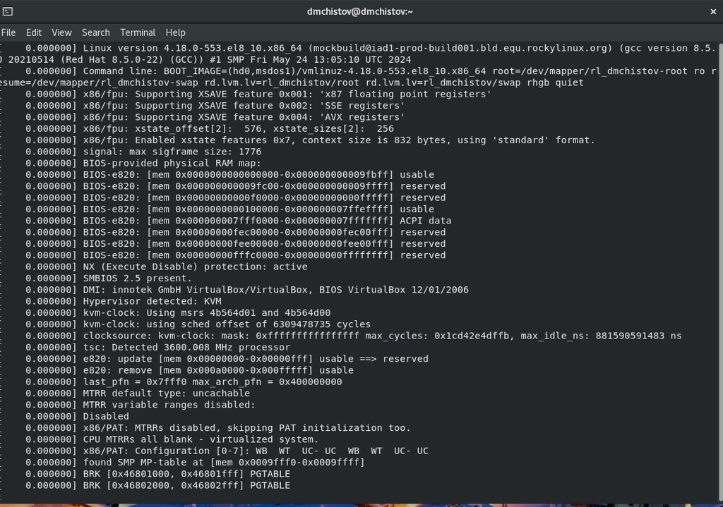

Вывод команды dmesg | less

## Домашнее задание

Используя dmesg | grep -i “” (в кавычках пишу то, что ищу), нахожу всё, что мне надо по заданию.

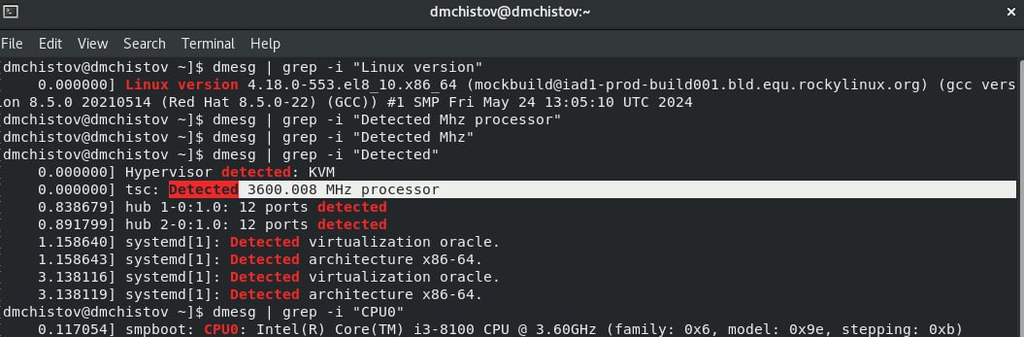

Linux Version, Mhz processor, CPU0

## Домашнее задание

Также узнаю о кол-ве доступной памяти, типе гипервизора, типе файловой системы и о последовательности монтирования файловых систем.

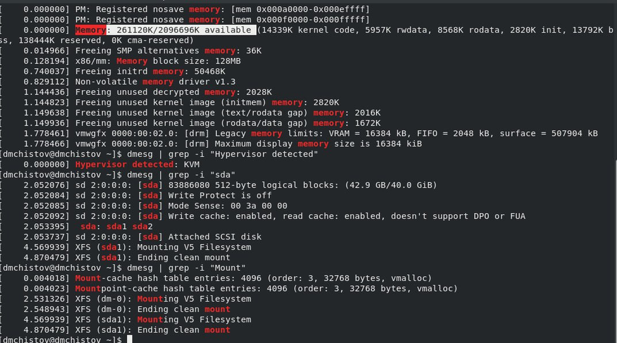

кол-во доступной памяти, тип гипервизора, тип файловой системы, последовательность монтирования файловых систем

# Выводы

При выполнении данной лаборатоной работы я приобрёл практические навыки установки операционной системы на виртуальную машину, настройки минимально необходимых для дальнейшей работы сервисов

# Список литературы

[Лабораторная работы №1](https://esystem.rudn.ru/pluginfile.php/2580589/mod_folder/content/0/001-lab_virtualbox.pdf)

[Команда dmesg](https://phoenixnap.com/kb/dmesg-linux#:~:text=The%20dmesg%20command%20is%20a,module%20messages%20during%20system%20startup)